# PS811 Portfolio - The Impact of Private Property Rights on Women’s Tenure in Africa

Lisa de Sousa Dias

## Research Question

While land lies at the heart of social, political, and economic life in Africa, women remain disadvantaged and discriminated against in existing land tenure regimes. In Kenya, for example, despite major constitutional and legislative reform, estimates suggest that only 1 per cent of land is registered to women alone and only 5 per cent of land is registered jointly with men. Much of the literature on women and land tenure in Africa focuses on questions surrounding customary land systems and specifically whether they provide greater protections for women. A dominant view in the literature and among policymakers is that land reform should build on customary land systems and existing institutions rather than break with them. These arguments are based on evidence that land titling and registration programs and the erosion of customary systems during and after independence were a setback for women.

Meanwhile, a growing number of feminist scholars and African women’s rights activists have challenged the claim that reforming customary systems advances women’s land interests. They claim that reforming customary systems reproduces gendered power imbalances especially evident as customary laws and practices have selectively preserved elements that subordinate women. Indeed, these scholars and activists argue that only right-based land systems and private property rights will enable women to break from the patriarchal power structures of customary land systems. Given contradicting and opposing views, I investigate how private property rights impact women’s tenure security using data from 16 countries in sub-Saharan Africa.

## Descriptive Statistics

```r
world <- map_data("world") %>% rename(country = region)

continent <- raster::ccodes() %>%
  rename(country = NAME)

world %<>% full_join(continent) # merge world dataset with dataset with continents

world %<>%
  filter(continent == "Africa") # filter for countries in Africa

landata <- read_csv("data/ssa_sigi_2019.csv")

landata %<>%
  mutate(tenure_security = as.numeric(tenure_security)) # transforming Tenure_Security into a numeric variable

landata %<>% rename(country = country_name) # change Country_Name to country

landata %>%  # changing name of Ivory Coast and DRC to match
  mutate(country = str_replace(country, "Ivory Coast" , "Côte d'Ivoire")) %>%
  mutate(country = str_replace(country, "DRC" , "Democratic Republic of the Congo"))
```

```
## # A tibble: 16 x 8
##    country tenure_security property_rights cpi_score arable_land
##    <chr>             <dbl>           <dbl>     <dbl>       <dbl>
##  1 Burkin…            0.08            0.25        41        21.9
##  2 Botswa…            0.35            0.5         61         0.5
##  3 Côte d…            0.1             1           35         9
##  4 "Democ…            0.09            0.5         20         3.1
##  5 Comoros            0.33            0.5         27        34.9
##  6 Cape V…            0.51            0           57        12
##  7 Ethiop…            0.19            0.25        34        15.1
##  8 Guinea             0.06            0.25        28        12.6
##  9 Gambia             0.08            0.5         37        43.5
## 10 Lesotho            0.31            0.25        41        11.6
## 11 Madaga…            0.15            0.25        25         6
## 12 Mozamb…            0.23            0.25        23         7.2
## 13 Malawi             0.32            0.25        32        40.3
## 14 Tanzan…            0.2             0.25        36        15.2
## 15 Uganda             0.16            1           26        34
## 16 Zambia             0.19            0.25        35         5.1
## # ... with 3 more variables: share_labor_agriculture <dbl>, gdp <dbl>,
## #   rural_population <dbl>
```

```r
world %<>% full_join(landata) # joining world and landdata
```

### Share of Labor Force Employed in Agriculture

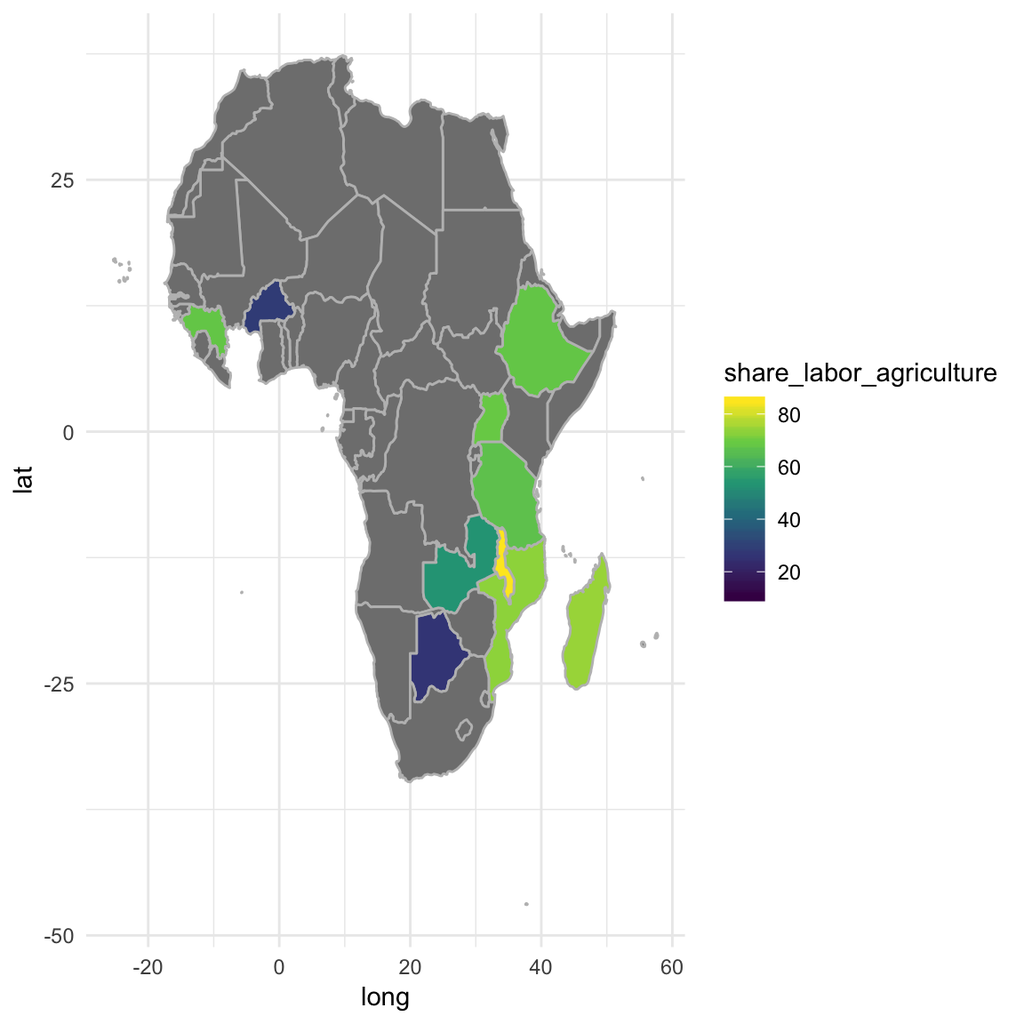

```r
# Map of share of labor force employed in agriculture

world %>%
  ggplot( aes(x = long, y = lat) ) +
  geom_polygon( aes(group = group, fill = share_labor_agriculture), color = "grey") +
  scale_fill_viridis_c()
```

### Women’s Tenure Security

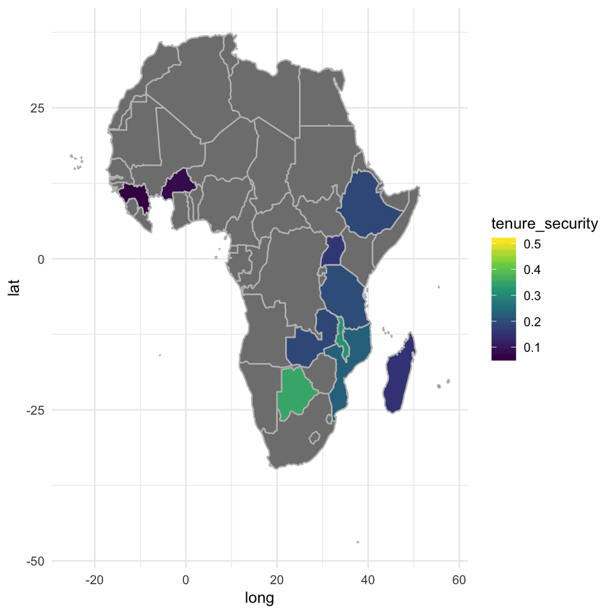

```r
# Map of women's tenure security

world %>%
  ggplot( aes(x = long, y = lat) ) +
  geom_polygon( aes(group = group, fill = tenure_security), color = "grey") +
  scale_fill_viridis_c()
```

### Strength of Private Property Rights

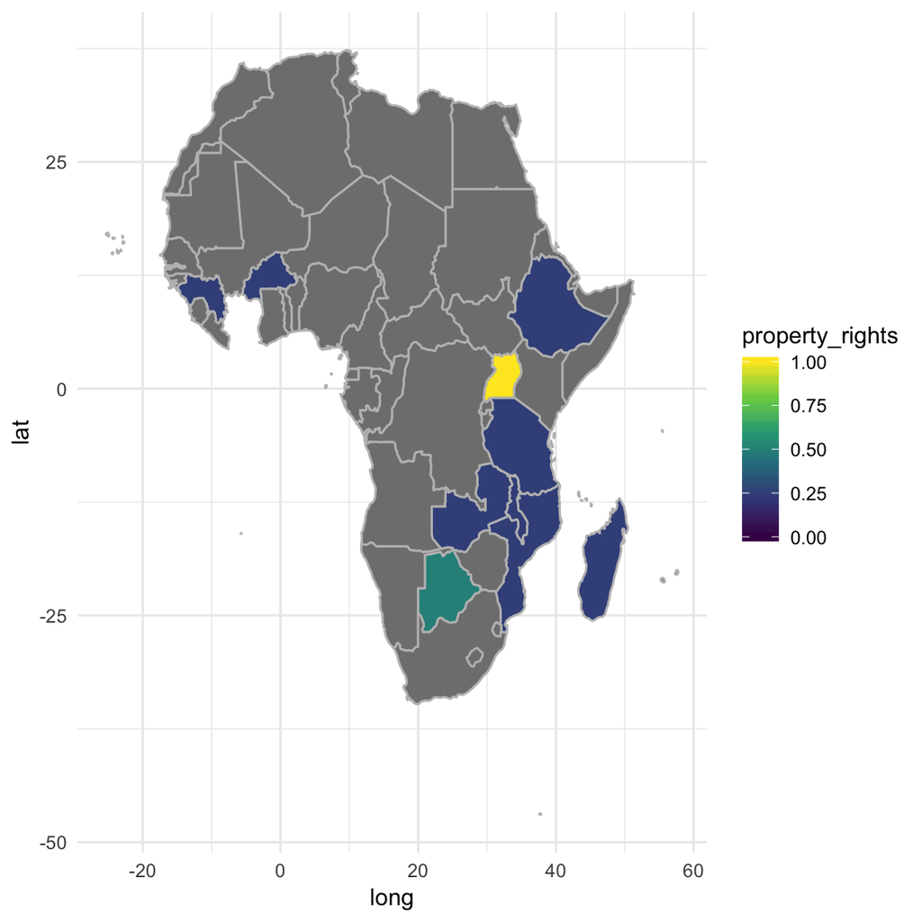

```r
# Map of property rights

world %>%
  ggplot( aes(x = long, y = lat) ) +
  geom_polygon( aes(group = group, fill = property_rights), color = "grey") +
  scale_fill_viridis_c()
```

## Analysis

### OLS Regression

```r
# OLS regression

d <- landata

model <- lm(d$tenure_security ~ d$property_rights + d$arable_land + d$share_labor_agriculture + d$cpi_score + d$rural_population)

summary(model)
```

```
##
## Call:
## lm(formula = d$tenure_security ~ d$property_rights + d$arable_land +
##     d$share_labor_agriculture + d$cpi_score + d$rural_population)
##
## Residuals:
##       Min        1Q    Median        3Q       Max
## -0.152337 -0.061722 -0.004635  0.031339  0.178471
##
## Coefficients:
##                            Estimate Std. Error t value Pr(>|t|)
## (Intercept)               -0.330880   0.301163  -1.099   0.2977
## d$property_rights         -0.066691   0.113647  -0.587   0.5703
## d$arable_land              0.000952   0.002199   0.433   0.6743
## d$share_labor_agriculture  0.002267   0.001540   1.472   0.1719
## d$cpi_score                0.009759   0.003775   2.585   0.0272 *
## d$rural_population         0.001336   0.002387   0.560   0.5881
## ---
## Signif. codes:  0 '***' 0.001 '**' 0.01 '*' 0.05 '.' 0.1 ' ' 1
##
## Residual standard error: 0.1067 on 10 degrees of freedom
## Multiple R-squared:  0.5183, Adjusted R-squared:  0.2775
## F-statistic: 2.152 on 5 and 10 DF,  p-value: 0.1415
```

### Plot of Residuals

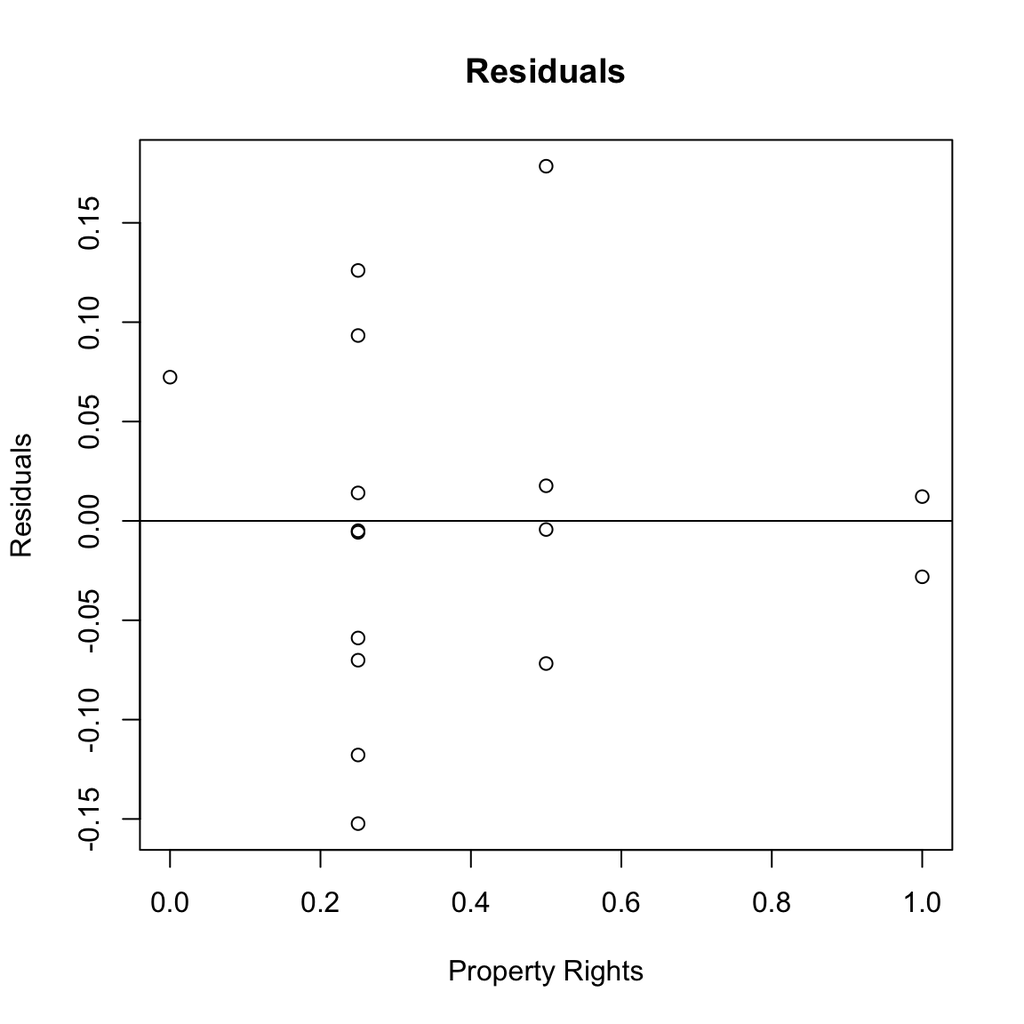

```
## integer(0)
```

```r
# Plot of residuals

residuals.model <- resid(model)

plot(d$property_rights, residuals.model,
     ylab = "Residuals", xlab = "Property Rights",
     main = "Residuals") +
  abline(0,0)
```

### Case-Study of Kenya - Logistic Model

```r
kenya <- read_csv("data/Kenya_download_V1.csv")

kenya %<>%
  rename(country = Q3) %>%
  rename(sex = Q21_Gender) %>%
  rename(formaldocs = Q55_any_formal) %>%
  rename(tenuresecurity = Q45_security)

myvariables <- c("country", "sex", "formaldocs", "tenuresecurity")

kenyadata <- kenya[myvariables]

m2 <- glm(factor(tenuresecurity) ~ formaldocs*sex, data = kenyadata, family = "binomial")

summary(m2)
```

```
##
## Call:
## glm(formula = factor(tenuresecurity) ~ formaldocs * sex, family = "binomial",
##     data = kenyadata)
##
## Deviance Residuals:
##     Min       1Q   Median       3Q      Max
## -2.6972   0.2357   0.3077   0.3764   0.3764
##
## Coefficients:
##                                               Estimate Std. Error z value
## (Intercept)                                     2.6117     0.1423  18.352
## formaldocsYes, formal documents exist           0.9578     0.3857   2.483
## sexMale                                         0.4150     0.2431   1.707
## formaldocsYes, formal documents exist:sexMale  -0.3736     0.5493  -0.680
##                                               Pr(>|z|)
## (Intercept)                                     <2e-16 ***
## formaldocsYes, formal documents exist           0.0130 *
## sexMale                                         0.0878 .
## formaldocsYes, formal documents exist:sexMale   0.4964
## ---
## Signif. codes:  0 '***' 0.001 '**' 0.01 '*' 0.05 '.' 0.1 ' ' 1
##
## (Dispersion parameter for binomial family taken to be 1)
##
##     Null deviance: 775.60  on 1992  degrees of freedom
## Residual deviance: 761.95  on 1989  degrees of freedom
## AIC: 769.95
##
## Number of Fisher Scoring iterations: 6
```

## Data Sources

- Social Institutions and Gender Index ( [data](https://www.genderindex.org/data/) )
- Transparency International Corruption Perception Index ( [data](https://www.transparency.org/cpi2018) )
- Prindex data on perceptions of land and property rights ( [data](https://www.prindex.net/data/) )
- World Bank indicators ( [data](https://datacatalog.worldbank.org/dataset/world-development-indicators) )